# Analysis of U.S. Storm Event Data and the Impact on Population Health and the Economy

Suhas P K

2023-05-17

# Course Project

**Reproducible Research : Project 2** The course project is available on [Reproducible Research : Project 2](https://github.com/SuhasPK/RepData_Peer_Assignment2)

# Synopsis

Storm and other extreme weather events can cause both public health and economic problems. Many extreme events results in fatalities, injuries, and property damage. Preventing such outcomes to the extent possible is a key concern. The published report contains the result of analysis where the goal was to identify the most hazardous weather events with respect to population health and those with greatest economic impact in the U.S. based on data collected from U.S. National Oceanic and Atmospheric Administration (NOAA).

## Libraries used

```r
if (!require(ggplot2)){
    install.packages("ggplot")
    library(ggplot2)
}
if (!require(dplyr)) {
    install.packages("dplyr")
    library(dplyr, warn.conflicts = FALSE)
}
if (!require(xtable)) {
    install.packages("xtable")
    library(xtable, warn.conflicts = FALSE)
}
if (!require(htmlTable)){
    install.packages("htmlTables")
    library(htmlTable, warn.conflicts = FALSE)
}
```

Obtaining dataset.

```r
# Url and path
url <- "https://d396qusza40orc.cloudfront.net/repdata%2Fdata%2FStormData.csv.bz2"
destfile <- paste(getwd(), "stormdata.csv", sep = "/")

# DOWNLOAD THE DATASET
if (!file.exists(destfile)){
    download.file(url = url,
              destfile = destfile,)
}
```

Loading the datasetand displaying the dataset summary.

```r
# READ THE .csv FILE
storm_Data <- read.csv("stormdata.csv")
names(storm_Data)
```

```
##  [1] "STATE__"    "BGN_DATE"   "BGN_TIME"   "TIME_ZONE"  "COUNTY"
##  [6] "COUNTYNAME" "STATE"      "EVTYPE"     "BGN_RANGE"  "BGN_AZI"
## [11] "BGN_LOCATI" "END_DATE"   "END_TIME"   "COUNTY_END" "COUNTYENDN"
## [16] "END_RANGE"  "END_AZI"    "END_LOCATI" "LENGTH"     "WIDTH"
## [21] "F"          "MAG"        "FATALITIES" "INJURIES"   "PROPDMG"
## [26] "PROPDMGEXP" "CROPDMG"    "CROPDMGEXP" "WFO"        "STATEOFFIC"
## [31] "ZONENAMES"  "LATITUDE"   "LONGITUDE"  "LATITUDE_E" "LONGITUDE_"
## [36] "REMARKS"    "REFNUM"
```

```r
str(storm_Data)
```

```
## 'data.frame':    902297 obs. of  37 variables:
##  $ STATE__   : num  1 1 1 1 1 1 1 1 1 1 ...
##  $ BGN_DATE  : chr  "4/18/1950 0:00:00" "4/18/1950 0:00:00" "2/20/1951 0:00:00" "6/8/1951 0:00:00" ...
##  $ BGN_TIME  : chr  "0130" "0145" "1600" "0900" ...
##  $ TIME_ZONE : chr  "CST" "CST" "CST" "CST" ...
##  $ COUNTY    : num  97 3 57 89 43 77 9 123 125 57 ...
##  $ COUNTYNAME: chr  "MOBILE" "BALDWIN" "FAYETTE" "MADISON" ...
##  $ STATE     : chr  "AL" "AL" "AL" "AL" ...
##  $ EVTYPE    : chr  "TORNADO" "TORNADO" "TORNADO" "TORNADO" ...
##  $ BGN_RANGE : num  0 0 0 0 0 0 0 0 0 0 ...
##  $ BGN_AZI   : chr  "" "" "" "" ...
##  $ BGN_LOCATI: chr  "" "" "" "" ...
##  $ END_DATE  : chr  "" "" "" "" ...
##  $ END_TIME  : chr  "" "" "" "" ...
##  $ COUNTY_END: num  0 0 0 0 0 0 0 0 0 0 ...
```

[output cut: 23 more lines]

```r
head(storm_Data)
```

```
##   STATE__           BGN_DATE BGN_TIME TIME_ZONE COUNTY COUNTYNAME STATE  EVTYPE
## 1       1  4/18/1950 0:00:00     0130       CST     97     MOBILE    AL TORNADO
## 2       1  4/18/1950 0:00:00     0145       CST      3    BALDWIN    AL TORNADO
## 3       1  2/20/1951 0:00:00     1600       CST     57    FAYETTE    AL TORNADO
## 4       1   6/8/1951 0:00:00     0900       CST     89    MADISON    AL TORNADO
## 5       1 11/15/1951 0:00:00     1500       CST     43    CULLMAN    AL TORNADO
## 6       1 11/15/1951 0:00:00     2000       CST     77 LAUDERDALE    AL TORNADO
##   BGN_RANGE BGN_AZI BGN_LOCATI END_DATE END_TIME COUNTY_END COUNTYENDN
## 1         0                                               0         NA
## 2         0                                               0         NA
## 3         0                                               0         NA
## 4         0                                               0         NA
## 5         0                                               0         NA
## 6         0                                               0         NA
##   END_RANGE END_AZI END_LOCATI LENGTH WIDTH F MAG FATALITIES INJURIES PROPDMG
```

[output cut: 20 more lines]

To view the dataset,

```r
head(storm_Data,10)
```

```
##    STATE__           BGN_DATE BGN_TIME TIME_ZONE COUNTY COUNTYNAME STATE
## 1        1  4/18/1950 0:00:00     0130       CST     97     MOBILE    AL
## 2        1  4/18/1950 0:00:00     0145       CST      3    BALDWIN    AL
## 3        1  2/20/1951 0:00:00     1600       CST     57    FAYETTE    AL
## 4        1   6/8/1951 0:00:00     0900       CST     89    MADISON    AL
## 5        1 11/15/1951 0:00:00     1500       CST     43    CULLMAN    AL
## 6        1 11/15/1951 0:00:00     2000       CST     77 LAUDERDALE    AL
## 7        1 11/16/1951 0:00:00     0100       CST      9     BLOUNT    AL
## 8        1  1/22/1952 0:00:00     0900       CST    123 TALLAPOOSA    AL
## 9        1  2/13/1952 0:00:00     2000       CST    125 TUSCALOOSA    AL
## 10       1  2/13/1952 0:00:00     2000       CST     57    FAYETTE    AL
##     EVTYPE BGN_RANGE BGN_AZI BGN_LOCATI END_DATE END_TIME COUNTY_END COUNTYENDN
## 1  TORNADO         0                                               0         NA
## 2  TORNADO         0                                               0         NA
## 3  TORNADO         0                                               0         NA
```

[output cut: 40 more lines]

## Data Processing

### Creating a subset of the dataset

For this analysis, the dataset will be reduced to only include the necessary variables. Only onservations with values greater than zero will be included.<

| **Variable** | **Description** |
| --- | --- |
| EVTYPE | Event type (Flood, Heat, Hurricane, Tornado, …) |
| FATALITIES | Number of fatalities resulting from event |
| INJURIES | Number of injuries resulting from event |
| PROPDMG | Property damage in USD |
| PROPDMGEXP | Unit multiplier for property damage (K, M, or B) |
| CROPDMG | Crop damage in USD |
| CROPDMGEXP | Unit multiplier for property damage (K, M, or B) |
| BGN_DATE | Begin date of the event |
| END_DATE | End date of the event |
| STATE | State where the event occurred |

```r
# TIDY DATA FROM STORM DATA
tidy_data <- subset(
    storm_Data, EVTYPE != "?" &
        (FATALITIES > 0 | INJURIES > 0 | PROPDMG > 0 | CROPDMG > 0),
    select = c("EVTYPE",
               "FATALITIES",
               "INJURIES",
               "PROPDMG",
               "PROPDMGEXP",
               "CROPDMG",
               "CROPDMGEXP",
               "BGN_DATE",
               "END_DATE",
               "STATE"
               )
)
```

To check the dimension of the tidy_data.

```r
dim(tidy_data)
```

```
## [1] 254632     10
```

Just to check if any NA values exists in the dataset.

```r
sum(is.na(tidy_data))
```

```
## [1] 0
```

## Data Cleaning, most important and boring part but very very IMPORTANT!

### Clean Event type data.

There are a total of487 unique Eventy Type values in teh current tidy data.

```r
length(unique(tidy_data$EVTYPE))
```

```
## [1] 487
```

Exploring the Event Type data revealed many values that appeared to be similar; however, they were entered with different spellings, pluralization, mixed case and even misspellings. For example, Strong Wind, STRONG WIND, Strong Winds, and STRONG WINDS. The dataset was normalized by converting all Event Type values to uppercase and combining similar Event Type values into unique categories.

```r
# converting all Event Type values to uppercase and combining similar Event Type values into unique categories.
tidy_data$EVTYPE <- toupper(tidy_data$EVTYPE)
```

A better approach can be taken but this is fool proof, which not a bad thing but also not a good practice in programming.

```r
# Avalanche
tidy_data$EVTYPE <- gsub('.*AVALANCE.*', 'AVALANCHE', tidy_data$EVTYPE)

# Blizzard
tidy_data$EVTYPE <- gsub('.*BLIZZARD.*', 'BLIZZARD', tidy_data$EVTYPE)

# Cloud
tidy_data$EVTYPE <- gsub('.*CLOUD.*', 'CLOUD', tidy_data$EVTYPE)

# Cold
tidy_data$EVTYPE <- gsub('.*COLD.*', 'COLD', tidy_data$EVTYPE)
tidy_data$EVTYPE <- gsub('.*FREEZ.*', 'COLD', tidy_data$EVTYPE)
tidy_data$EVTYPE <- gsub('.*FROST.*', 'COLD', tidy_data$EVTYPE)
tidy_data$EVTYPE <- gsub('.*ICE.*', 'COLD', tidy_data$EVTYPE)
tidy_data$EVTYPE <- gsub('.*LOW TEMPERATURE RECORD.*', 'COLD',tidy_data$EVTYPE)
tidy_data$EVTYPE <- gsub('.*LO.*TEMP.*', 'COLD',tidy_data$EVTYPE)

# Dry
tidy_data$EVTYPE <- gsub('.*DRY.*', 'DRY',tidy_data$EVTYPE)

# Dust
tidy_data$EVTYPE <- gsub('.*DUST.*', 'DUST',tidy_data$EVTYPE)

# Fire
tidy_data$EVTYPE <- gsub('.*FIRE.*', 'FIRE', tidy_data$EVTYPE)

# flood
tidy_data$EVTYPE <- gsub('.*FLOOD.*', 'FLOOD', tidy_data$EVTYPE)

# Fog
tidy_data$EVTYPE <- gsub('.*FOG.*', 'FOG', tidy_data$EVTYPE)

# Hail
tidy_data$EVTYPE <- gsub('.*HAIL.*', 'HAIL', tidy_data$EVTYPE)

# HEAT
tidy_data$EVTYPE <- gsub('.*HEAT.*', 'HEAT', tidy_data$EVTYPE)
tidy_data$EVTYPE <- gsub('.*WARM.*', 'HEAT', tidy_data$EVTYPE)
tidy_data$EVTYPE <- gsub('.*HIGH.*TEMP.*', 'HEAT', tidy_data$EVTYPE)
tidy_data$EVTYPE <- gsub('.*RECORD HIGH TEMPERATURES.*', 'HEAT', tidy_data$EVTYPE)

# Hypothermia
tidy_data$EVTYPE <- gsub('.*HYPOTHERMIA.*', 'HYPOTHERMIA/EXPOSURE',tidy_data$EVTYPE)

#Landslide
tidy_data$EVTYPE <- gsub('.*LANDSLIDE.*', 'LANDSLIDE', tidy_data$EVTYPE)

# Lightning
tidy_data$EVTYPE <- gsub('^LIGHTNING.*', 'LIGHTNING', tidy_data$EVTYPE)
tidy_data$EVTYPE <- gsub('^LIGNTNING.*', 'LIGHTNING', tidy_data$EVTYPE)
tidy_data$EVTYPE <- gsub('^LIGHTING.*', 'LIGHTNING', tidy_data$EVTYPE)

# Microburst
tidy_data$EVTYPE <- gsub('.*MICROBURST.*', 'MICROBURST', tidy_data$EVTYPE)

# Mudslide
tidy_data$EVTYPE <- gsub('.*MUDSLIDE.*', 'MUDSLIDE', tidy_data$EVTYPE)

# Rain
tidy_data$EVTYPE <-gsub('.*RAIN.*', 'RAIN', tidy_data$EVTYPE)
tidy_data$EVTYPE <- gsub('.*MUD SLIDE.*', 'MUDSLIDE', tidy_data$EVTYPE)

# Rip current
tidy_data$EVTYPE <- gsub('.*RIP CURRENT.*', 'RIP CURRENT', tidy_data$EVTYPE)

# Storm
tidy_data$EVTYPE <- gsub('.*STORM.*', 'STORM', tidy_data$EVTYPE)

# Summary
tidy_data$EVTYPE <- gsub('.*SUMMARY.*', 'SUMMARY', tidy_data$EVTYPE)

# Tornado
tidy_data$EVTYPE <- gsub('.*TORNADO.*', 'TORNADO', tidy_data$EVTYPE)
tidy_data$EVTYPE <- gsub('.*TORNDAO.*', 'TORNADO', tidy_data$EVTYPE)
tidy_data$EVTYPE <- gsub('.*LANDSPOUT.*', 'TORNADO', tidy_data$EVTYPE)
tidy_data$EVTYPE <- gsub('.*WATERSPOUT.*', 'TORNADO', tidy_data$EVTYPE)

# Surf
tidy_data$EVTYPE <- gsub('.*SURF.*', 'SURF', tidy_data$EVTYPE)

# Volcanic
tidy_data$EVTYPE <- gsub('.*VOLCANIC.*', 'VOLCANIC', tidy_data$EVTYPE)

# Wet
tidy_data$EVTYPE <- gsub('.*WET.*', 'WET', tidy_data$EVTYPE)

# Wind
tidy_data$EVTYPE <- gsub('.*WIND.*', 'WIND', tidy_data$EVTYPE)

# Winter
tidy_data$EVTYPE <- gsub('.*WINTER.*', 'WINTER', tidy_data$EVTYPE)
tidy_data$EVTYPE <- gsub('.*WINTRY.*', 'WINTER', tidy_data$EVTYPE)
tidy_data$EVTYPE <- gsub('.*SNOW.*', 'WINTER', tidy_data$EVTYPE)
```

After tidying the dataset, the number of unique Event Type values were reduced to 81.

```r
# Number of unique event type value
length(unique(tidy_data$EVTYPE))
```

```
## [1] 81
```

### Cleaning Date type data.

Format date variables for any type of optional reporting or further analysis.

Create four new variables based on date variables in the tidy dataset:

[output not shown]

```r
# Cleaning Date data
tidy_data$DATE_START <- as.Date(tidy_data$BGN_DATE, format = "%m/%d/%Y")
tidy_data$DATE_END <- as.Date(tidy_data$END_DATE, format = "%m/%d/%Y")
tidy_data$YEAR <- as.integer(format(tidy_data$DATE_START, "%Y"))
tidy_data$DURATION <- as.numeric(tidy_data$DATE_END - tidy_data$DATE_START)/3600
```

### Cleaning Economic data

According to the “National Weather Service [Storm Data Documentation](https://d396qusza40orc.cloudfront.net/repdata%2Fpeer2_doc%2Fpd01016005curr.pdf)” (page 12), information about Property Damage is logged using two variables: PROPDMG and PROPDMGEXP. PROPDMG is the mantissa (the significand) rounded to three significant digits and PROPDMGEXP is the exponent (the multiplier). The same approach is used for Crop Damage where the CROPDMG variable is encoded by the CROPDMGEXP variable. The documentation also specifies that the PROPDMGEXP and CROPDMGEXP are supposed to contain an alphabetical character used to signify magnitude and logs “K” for thousands, “M” for millions, and “B” for billions. A quick review of the data, however, shows that there are several other characters being logged.

```r
# Cleaning Economic Data
table(toupper(tidy_data$PROPDMGEXP))
```

```
##
##             -      +      0      2      3      4      5      6      7      B
##  11585      1      5    210      1      1      4     18      3      3     40
##      H      K      M
##      7 231427  11327
```

```r
table(toupper(tidy_data$CROPDMGEXP))
```

```
##
##             ?      0      B      K      M
## 152663      6     17      7  99953   1986
```

n order to calculate costs, the PROPDMGEXP and CROPDMGEXP variables will be mapped to a multiplier factor which will then be used to calculate the actual costs for both property and crop damage. Two new variables will be created to store damage costs:

- PROP_COST
- CROP_COST

```r
# function to get multiplier factor
getMultiplier <- function(exp) {
    exp <- toupper(exp);
    if (exp == "")  return (10^0);
    if (exp == "-") return (10^0);
    if (exp == "?") return (10^0);
    if (exp == "+") return (10^0);
    if (exp == "0") return (10^0);
    if (exp == "1") return (10^1);
    if (exp == "2") return (10^2);
    if (exp == "3") return (10^3);
    if (exp == "4") return (10^4);
    if (exp == "5") return (10^5);
    if (exp == "6") return (10^6);
    if (exp == "7") return (10^7);
    if (exp == "8") return (10^8);
    if (exp == "9") return (10^9);
    if (exp == "H") return (10^2);
    if (exp == "K") return (10^3);
    if (exp == "M") return (10^6);
    if (exp == "B") return (10^9);
    return (NA);
}

# calculate property damage and crop damage costs (in billions)
tidy_data$PROP_COST <- with(tidy_data, as.numeric(PROPDMG) * sapply(PROPDMGEXP, getMultiplier))/10^9
tidy_data$CROP_COST <- with(tidy_data, as.numeric(CROPDMG) * sapply(CROPDMGEXP, getMultiplier))/10^9
```

## Summarize Data

Create a summarized dataset of health impact data (fatalities + injuries). Sort the results in descending order by health impact.

```r
# Create a summarise data of health impact data (fatalities + injuries).
health_impact_data <- aggregate(
    x = list(HEALTH_IMPACT = tidy_data$FATALITIES + tidy_data$INJURIES),
    by = list(EVENT_TYPE = tidy_data$EVTYPE),
    FUN = sum,
    na.rm = TRUE
)
health_impact_data <- health_impact_data[order(health_impact_data$HEALTH_IMPACT,
                                               decreasing = TRUE),]
row.names(health_impact_data) <- NULL
```

Create a summarized dataset of damage impact costs (property damage + crop damage). Sort the results in descending order by damage cost.

```r
# Create a summarise dataset of damage impact cost (property damage + crop damage).
damage_costImpact_data <- aggregate(
    x = list(DAMAGE_IMPACT = tidy_data$PROP_COST + tidy_data$CROP_COST),
    by = list(EVENT_TYPE = tidy_data$EVTYPE),
    FUN = sum,
    na.rm = TRUE
)
damage_costImpact_data <- damage_costImpact_data[order(damage_costImpact_data$DAMAGE_IMPACT,
                                                       decreasing = TRUE),]
row.names(damage_costImpact_data) <- NULL
```

## Result

### Event Types Most Harmful to Population Health

Fatalities and injuries have the most harmful impact on population health. The results below display the 10 most harmful weather events in terms of population health in the U.S.

```r
# Event types most harmful to population health.
htmlTable(head(health_impact_data,10),
          caption = "Top 10 Weather Events with Most harmful events to population health. "

          )
```

| Top 10 Weather Events with Most harmful events to population health. | Top 10 Weather Events with Most harmful events to population health. EVENT_TYPE | Top 10 Weather Events with Most harmful events to population health. HEALTH_IMPACT |
| --- | --- | --- |
| 1 | TORNADO | 97075 |
| 2 | HEAT | 12392 |
| 3 | FLOOD | 10127 |
| 4 | WIND | 9893 |
| 5 | LIGHTNING | 6049 |
| 6 | STORM | 4780 |
| 7 | COLD | 3100 |
| 8 | WINTER | 1924 |
| 9 | FIRE | 1698 |
| 10 | HAIL | 1512 |

For dark themed plot use,

```r
library(ggdark)
```

Code for Plotting.

```r
health_impact_chart <- ggplot(head(health_impact_data,10),
                              aes(x=reorder(EVENT_TYPE, HEALTH_IMPACT),
                                  y = HEALTH_IMPACT, fill = EVENT_TYPE)) +
    coord_flip() +
    geom_bar(stat = "identity") +
    xlab("Event Type") +
    ylab("Total Fatalities and Injuries") +
    theme(plot.title = element_text(size = 14, hjust = 0.5)) +
    ggtitle("Top 10 Weather Events Most Harmful to \nPopulation Health")+
    dark_theme_grey()
```

```
## Inverted geom defaults of fill and color/colour.
## To change them back, use invert_geom_defaults().
```

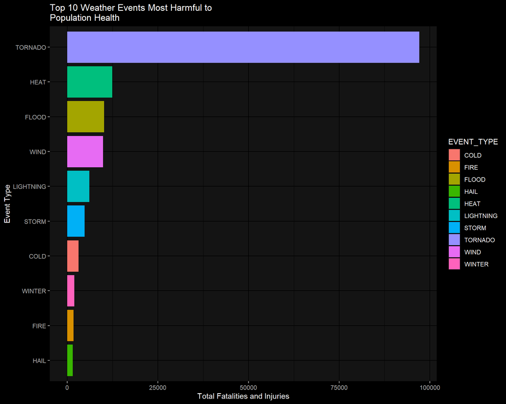

```r
print(health_impact_chart)
```

### Event Types with Greatest Economic Consequences

Property and crop damage have the most harmful impact on the economy. The results below display the 10 most harmful weather events in terms economic consequences in the U.S.

```r
htmlTable(head(damage_costImpact_data,10),
          caption = "Top 10 Weather Events with Greatest Economic Consequences"

          )
```

| Top 10 Weather Events with Greatest Economic Consequences | Top 10 Weather Events with Greatest Economic Consequences EVENT_TYPE | Top 10 Weather Events with Greatest Economic Consequences DAMAGE_IMPACT |
| --- | --- | --- |
| 1 | FLOOD | 180.58155793491 |
| 2 | HURRICANE/TYPHOON | 71.9137128 |
| 3 | STORM | 70.4499388701 |
| 4 | TORNADO | 57.4278510465 |
| 5 | HAIL | 20.7372044097 |
| 6 | DROUGHT | 15.018672 |
| 7 | HURRICANE | 14.61022901 |
| 8 | COLD | 12.69943621 |
| 9 | WIND | 12.005544868 |
| 10 | FIRE | 8.90491013 |

Code for plotting.

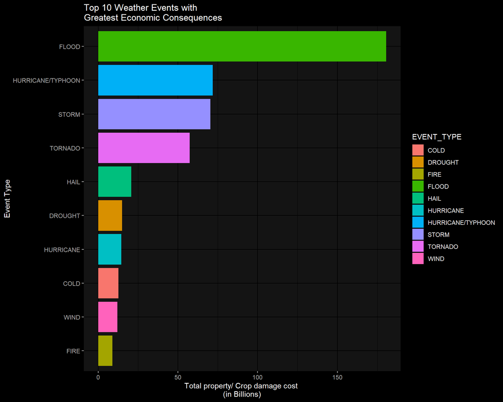

```r
damage_costImpact_chart <- ggplot(
    head(damage_costImpact_data,10),
    aes(x = reorder(EVENT_TYPE, DAMAGE_IMPACT),
        y = DAMAGE_IMPACT, fill = EVENT_TYPE)) +
    coord_flip() +
    geom_bar(stat = 'identity') +
    xlab("Event Type") +
    ylab("Total property/ Crop damage cost \n(in Billions)") +
    theme(plot.title = element_text(size = 14, hjust = 0.7 )) +
    ggtitle("Top 10 Weather Events with \nGreatest Economic Consequences")+
    dark_theme_grey()
print(damage_costImpact_chart)
```

## Conclusion

Based on the evidence demonstrated in this analysis and supported by the included data and graphs, the following conclusions can be drawn:

- **Which types of weather events are most harmful to population health?** Tornadoes are responsible for the greatest number of fatalities and injuries.
- **Which types of weather events have the greatest economic consequences?** Floods are responsible for causing the most property damage and crop damage costs.